# PS1 - Econometrics I

Gustavo Henrique and Bruno Tonholo

2024-10-15

## Problem Set 1

### Question 1

```r
# Setting objects
c = matrix(c(12547, 4818, 3440, 8583, 6657, 4990, 14493, 7990, 6139, 7043, 3758, 1487, 13238, 11033, 4921),
           nrow = 5,
           ncol = 3,
           byrow = TRUE)
p = c(1.05, 1.04, 1.1)
r = c(1.1, 1.09, 1.14)
alpha = 0.18

# Estimating beta using MME
beta_1 = c()
for (i in 1:nrow(c)) {
  c_1 = c[i, 1]
  c_2 = c[i, 2]
  p_1 = p[1]
  r_2 = r[2]
  beta_1[i] = (p_1*c_1^(-alpha))/(r_2*c_2^(-alpha))
}
beta_hat_1 = sum(beta_1)/length(beta_1)
beta_2 = c()
for (i in 1:nrow(c)) {
  c_2 = c[i, 2]
  c_3 = c[i, 3]
  p_2 = p[2]
  r_3 = r[3]
  beta_2[i] = (p_2*c_2^(-alpha))/(r_3*c_3^(-alpha))
}
beta_hat_2 = sum(beta_2)/length(beta_2)

# Beta estimates
print(c(beta_hat_1, beta_hat_2))
```

```
## [1] 0.8778034 0.8311448
```

### Question 2

Notice that
$$J(\beta) = \beta'A\beta
\\ = \begin{pmatrix} \beta_1 & \beta_2 \end{pmatrix} \begin{pmatrix}
a_{11} & a_{12} \\
a_{21} & a_{22}
\end{pmatrix} \begin{pmatrix} \beta_1 \\ \beta_2 \end{pmatrix} \\
= \sum_{i=1}^2\sum_{j=1}^2\beta_i\beta_ja_{ij} \\ = \beta_1^2a_{11} +
\beta_2^2a_{22} + \beta_1\beta_2a_{21} + \beta_1\beta_2a_{12}$$
Hence, the partial derivative of $J(\beta)$ w. r. t. $\beta_i$ is
$$\frac{\partial J(\beta)}{\partial \beta_i} = 2\beta_ia_{ii} +
\beta_ja_{ij} + \beta_ja_{ij}$$
We can then write the Jacobian matrix $\frac{\partial J(\beta)}{\partial \beta}$ as a vector of these partial derivatives
$$\frac{\partial J(\beta)}{\partial \beta} = (A +
A')\beta$$
Therefore, $\frac{\partial J(\beta)}{\partial \beta} = 2A\beta$ if and only if A is symmetric, i.e. if and only if $a_{ij}=a_{ji}, \forall i \neq j$.

### Question 3

We know that $Cov(e)=\Sigma$, for a random vector $e$. Hence, for some nonstochastic matrix $A \in \mathbb{R}^{k \times n}$, we have
$$Cov(Ae) =
ACov(e)A' = A \Sigma A'$$
by the property of the variance-covariance matrix.

### Question 4

Since $\mathbb{E}[e|z]=0$, by the Law of Iterated Expectations (LIE), we have
$$\mathbb{E}[z'e]=\mathbb{E}[\mathbb{E}[z'e|z]]=\mathbb{E}[z'\mathbb{E}[e|z]]=0$$
and
$$Var(z'e)=\mathbb{E}[z'e(z'e)']=\mathbb{E}[z'ee'z]=\mathbb{E}[\mathbb{E}[z'ee'z|z]]=\mathbb{E}[z'\mathbb{E}[ee'|z]z]$$
Let $\mathbb{E}[ee'|z]=\Sigma$ be the covariance matrix of $e$. Hence, we have $Var(z'e)=z' \Sigma z$. Therefore,
$$(z'e) \sim \mathcal{N}(0,
z' \Sigma z)$$

### Question 5

Notice 1st that since $x$ is uniformly distributed, we have
$$f(x) =
\begin{cases}
\frac{1}{b-a}, & \text{if } x \in [a, b] \\
0, & \text{otherwise }
\end{cases}$$
Now, we know that the kernel density estimator is given by:
$$\hat{f}\left(x_0\right)=\frac{1}{n h}
\sum_{i=1}^nK\left(\frac{x_i-x_0}{h}\right)$$
Since we are using a triangular kernel, $h=2$ and given $z = \frac{x_i-x_0}{h}$,it is possible to write the kernel density estimator the following way:
$$\hat{f}\left(x_0\right)=\frac{1}{2n}
\sum_{i=1}^n (1-|z|) I(|z|<1)$$
Assuming i.i.d. draws, we obtain
$$\mathbb{E}[\hat{f}(x_0)] = \int
K(z) f\left(x_0+z h\right) d z = \frac{1}{b-a}\int_{-1}^{1} 1-|z|dz =
\frac{1}{b-a}$$
Therefore, we have
$$Bias[\hat{f}(x_0)] = \mathbb{E}[\hat{f}(x_0)] - {f}(x_0) = \frac{1}{b-a}
- \frac{1}{b-a} = 0$$
So, in this particular case the estimator is unbiased.

### Question 6

```r
# Loading data
pacman::p_load(
  here
)
iv_data = readRDS(here("problem_sets/data", "iv_data.Rds"))
```

1. The jacobian of $\bar{g}_n(\beta)$ is
   $$G_n(\beta)= \frac{\partial
   \bar{g_n}(\beta)}{\partial \beta}=-\frac{1}{n}\sum_{i=1}^n z_i x'_i$$
   which does not depend on $\beta$.
2. Notice that, with the identity matrix as the weighting matrix, we get
   $$J(\beta)=\bar{g}'_n(\beta)W_n\bar{g}_n(\beta)=\bar{g}'_n(\beta)\bar{g}_n(\beta)$$
   Hence, by coding

```r
# Seting the variables
y = iv_data[, 1] # Dependent variable
x = as.matrix(iv_data[, 2:3]) # Endogenous variables
z = as.matrix(iv_data[, 4:6]) # Instruments

# Defining the moment function and the objective function
g_n = function(beta){
  u = y - x%*%beta
  g_n_beta = colMeans(sweep(z, 1, u, `*`))
  return(g_n_beta)
}
J_beta = function(beta){
  g_n_beta = g_n(beta)
  return(t(g_n_beta) %*% g_n_beta)
}

# Minimizing the objective function
result = optim(par = c(0, 0), fn = J_beta)

# Printing the result
beta_hat = result$par
objective_value = result$value
```

we obtain

```r
cat("Beta estimate:", beta_hat, "\n")
```

```
## Beta estimate: 2.04522 5.083122
```

```r
cat("Objective function value:", objective_value, "\n")
```

```
## Objective function value: 0.002006452
```

3. By using $\hat{\beta}$, we obtain

```r
# Defining the "g_i" function for each observation i
g_i = function(i, beta){
  u_i = as.numeric(y[i] - x[i, ] %*% beta)
  g_i_beta = z[i, ] * u_i
  return(g_i_beta)
}

# Calculating S_hat
S_hat = matrix(0, ncol = 3, nrow = 3)
n = nrow(iv_data) # Nº of observations
for (i in 1:n) {
  g_i_beta_hat = g_i(i, beta_hat)
  S_hat = S_hat + g_i_beta_hat %*% t(g_i_beta_hat)
}
S_hat = S_hat/n
S_hat
```

```
##              z1         z2         z3
## [1,]  0.6820672  0.2305556 -0.1247409
## [2,]  0.2305556  0.9947676 -0.1807458
## [3,] -0.1247409 -0.1807458  0.8848954
```

4. By repeiting step 2

```r
# Redefining the objective function using S_hat
S_hat_inv = solve(S_hat)
J_beta_opt = function(beta){
  g_n_beta = g_n(beta)
  return(t(g_n_beta) %*% S_hat_inv %*% g_n_beta)
}

# Minimizing the objective function
result_opt = optim(par = c(0, 0), fn = J_beta_opt)

# Printing the result
beta_hat_opt = result_opt$par
```

we obtain

```r
cat("Beta estimate:", beta_hat_opt, "\n")
```

```
## Beta estimate: 2.020942 5.087925
```

5. Encoding

```r
# Defining the Jacobian G_n(β)
G_n = function(beta) {
  n = nrow(iv_data)         # Nº of observations
  g_n_beta = g_n(beta)      # Calculating g_n(β)

  # Initialize the Jacobian matrix G_n(β)
  G_n_matrix = matrix(0, nrow = 3, ncol = 2)

  # Calculating the Jacobian
  for (i in 1:n) {
    u_i = y[i] - x[i, ] %*% beta
    for (j in 1:2) {
      # Partial derivatives of g_n(β) with respect to β_j
      G_n_matrix[, j] = G_n_matrix[, j] + z[i, ] * (-x[i, j]) * (1/n)
    }
  }

  return(G_n_matrix)
}

# Calculate the Jacobian in beta_hat
G_hat = G_n(beta_hat)

# Result
G_hat
```

```
##            [,1]       [,2]
## [1,] -0.5735381 -0.1217397
## [2,] -0.1482957 -0.4815955
## [3,] -0.0452046 -0.6003229
```

6. Finally

```r
# Calculating the product G_hat' S_hat^{-1} G_hat
G_hat_transpose = t(G_hat)
product = G_hat_transpose %*% S_hat_inv %*% G_hat

# Calculating the covariance matrix V_GMM
V_GMM = (1/n) * solve(product)

# Resultado
V_GMM
```

```
##             [,1]        [,2]
## [1,]  0.04348864 -0.01078051
## [2,] -0.01078051  0.02773625
```

### Question 7

Encoding

```r
# Loading needed packages
pacman::p_load(
  tidyverse,
  fixest
)

# Importing the database
temperature_states = readRDS(here("problem_sets/data", "temperature_states.Rds"))

# Step 1: Calculate the national average daily maximum temperature
national_avg_temp = temperature_states %>%
  group_by(date) %>% # Group by date
  # Calculate the average max temperature
  summarise(avg_temp = mean(mean_tmax, na.rm = TRUE))

# Step 2: Count the number of days with average temperature above 32°C per year-month
days_above_32C = national_avg_temp %>%
  mutate(year_month = format(date, "%Y-%m")) %>% # Create a year-month column
  # Filter for temperatures above 32°C
  filter(avg_temp > 32) %>%
  group_by(year_month) %>% # Group by year-month
  summarise(days_above_32C = n()) %>% # Count the days
  # Add columns for the year and month
  mutate(year = as.numeric(substring(year_month, 1, 4)),
         month = as.numeric(substring(year_month, 6, 7)))

# Step 3: Regression of the count of days above 32°C on calendar year with month fixed effects
# Perform regression using fixest
model = feols(days_above_32C ~ year | month, data = days_above_32C)

# Display regression results
summary(model)
```

```
## OLS estimation, Dep. Var.: days_above_32C
## Observations: 152
## Fixed-effects: month: 9
## Standard-errors: Clustered (month)
##      Estimate Std. Error t value   Pr(>|t|)
## year 0.359033   0.071132 5.04742 0.00099243 ***
## ---
## Signif. codes:  0 '***' 0.001 '**' 0.01 '*' 0.05 '.' 0.1 ' ' 1
## RMSE: 5.80586     Adj. R2: 0.248835
##                 Within R2: 0.143741
```

```r
# Step 4: Repeat the analysis for each region
results_by_region = lapply(unique(temperature_states$region), function(reg) {
  # Filter the data for the specific region
  region_data = temperature_states %>%
    filter(region == reg)  # Keep only the rows for the current region

  # Calculate the average daily temperature for the region
  region_avg_temp = region_data %>%
    group_by(date) %>%  # Group by date
    # Calculate average max temperature for the region
    summarise(avg_temp = mean(mean_tmax, na.rm = TRUE))

  # Count the number of days with average temperature above 32°C per year-month for the region
  region_days_above_32C = region_avg_temp %>%
    mutate(year_month = format(date, "%Y-%m")) %>% # Create a year-month column
    filter(avg_temp > 32) %>% # Filter for temperatures above 32°C
    group_by(year_month) %>% # Group by year-month
    summarise(days_above_32C = n()) %>% # Count the days
    # Add columns for the year and month
    mutate(year = as.numeric(substring(year_month, 1, 4)),
           month = as.numeric(substring(year_month, 6, 7)))

  # Perform regression for the region
  model_region = feols(days_above_32C ~ year | month,
                       data = region_days_above_32C)

  # Return the region name and model
  return(list(region = reg, model = model_region))
})

# Display results by region
results_by_region
```

```
## [[1]]
## [[1]]$region
## [1] 1
##
## [[1]]$model
## OLS estimation, Dep. Var.: days_above_32C
## Observations: 252
## Fixed-effects: month: 12
## Standard-errors: Clustered (month)
##      Estimate Std. Error t value Pr(>|t|)
## year 0.125457   0.042018 2.98577 0.012391 *
## ---
## Signif. codes:  0 '***' 0.001 '**' 0.01 '*' 0.05 '.' 0.1 ' ' 1
## RMSE: 4.72268     Adj. R2: 0.788718
##                 Within R2: 0.031561
##
##
## [[2]]
## [[2]]$region
## [1] 2
##
## [[2]]$model
## OLS estimation, Dep. Var.: days_above_32C
## Observations: 223
## Fixed-effects: month: 12
## Standard-errors: Clustered (month)
##      Estimate Std. Error t value Pr(>|t|)
## year 0.203872   0.077255 2.63897 0.023036 *
## ---
## Signif. codes:  0 '***' 0.001 '**' 0.01 '*' 0.05 '.' 0.1 ' ' 1
## RMSE: 5.49997     Adj. R2: 0.674255
##                 Within R2: 0.05549
##
##
## [[3]]
## [[3]]$region
## [1] 3
##
## [[3]]$model
## OLS estimation, Dep. Var.: days_above_32C
```

[output cut: 28 more lines]

```
## [[5]]
## [[5]]$region
## [1] 5
##
## [[5]]$model
## OLS estimation, Dep. Var.: days_above_32C
## Observations: 212
## Fixed-effects: month: 12
## Standard-errors: Clustered (month)
##      Estimate Std. Error t value  Pr(>|t|)
## year 0.208735   0.049887 4.18418 0.0015258 **
## ---
## Signif. codes:  0 '***' 0.001 '**' 0.01 '*' 0.05 '.' 0.1 ' ' 1
## RMSE: 5.06976     Adj. R2: 0.586462
##                 Within R2: 0.072943
```

### Question 8

Encoding

```r
# Step 1: Calculate the average maximum temperature per month and per state
# Create a 'year-month' column
temperature_states = temperature_states %>%
  mutate(year_month = format(date, "%Y-%m")) # Format year-month

# Step 2: Calculate the average temperature (tmax) per state and per month
avg_temp_per_month = temperature_states %>%
  group_by(state, year_month) %>%
  summarise(avg_temp = mean(mean_tmax, na.rm = TRUE)) %>%
  mutate(year = as.numeric(substring(year_month, 1, 4)),
         month = as.numeric(substring(year_month, 6, 7)))
```

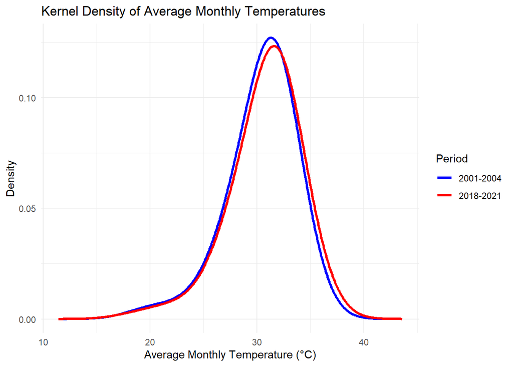

```r
# Step 3: Filter the data for the periods 2001-2004 and 2018-2021
avg_temp_2001_2004 = avg_temp_per_month %>%
  filter(year >= 2001 & year <= 2004)

avg_temp_2018_2021 = avg_temp_per_month %>%
  filter(year >= 2018 & year <= 2021)

# Step 4: Kernel density estimation using Gaussian kernel with bandwidth h = 2
# For the period 2001-2004
kde_2001_2004 = density(avg_temp_2001_2004$avg_temp, kernel = "gaussian", bw = 2)

# For the period 2018-2021
kde_2018_2021 = density(avg_temp_2018_2021$avg_temp, kernel = "gaussian", bw = 2)

# Step 5: Plot the two estimated density functions on top of each other
# Generate density values for both periods
plot_data_2001_2004 = data.frame(
  x = kde_2001_2004$x,
  density = kde_2001_2004$y,
  period = "2001-2004"
)

plot_data_2018_2021 = data.frame(
  x = kde_2018_2021$x,
  density = kde_2018_2021$y,
  period = "2018-2021"
)

# Combine the two datasets for plotting
plot_data = rbind(plot_data_2001_2004, plot_data_2018_2021)

# Step 6: Plot the densities using ggplot2
ggplot(plot_data, aes(x = x, y = density, color = period)) +
  geom_line(linewidth = 1.2) +
  labs(title = "Kernel Density of Average Monthly Temperatures",
       x = "Average Monthly Temperature (°C)",
       y = "Density",
       color = "Period") +
  theme_minimal() +
  scale_color_manual(values = c("2001-2004" = "blue", "2018-2021" = "red"))
```

### Question 9

Encoding

```r
# Loading needed package
pacman::p_load(
  np
)
# Step 1: Calculate the average maximum temperature per month and per state, as done previously
avg_temp_per_month_region = temperature_states %>%
  group_by(state, year_month, region, year) %>%
  summarise(avg_temp = mean(mean_tmax, na.rm = TRUE)) %>%
  mutate(year = as.numeric(substring(year_month, 1, 4)),
         month = as.numeric(substring(year_month, 6, 7)))
```

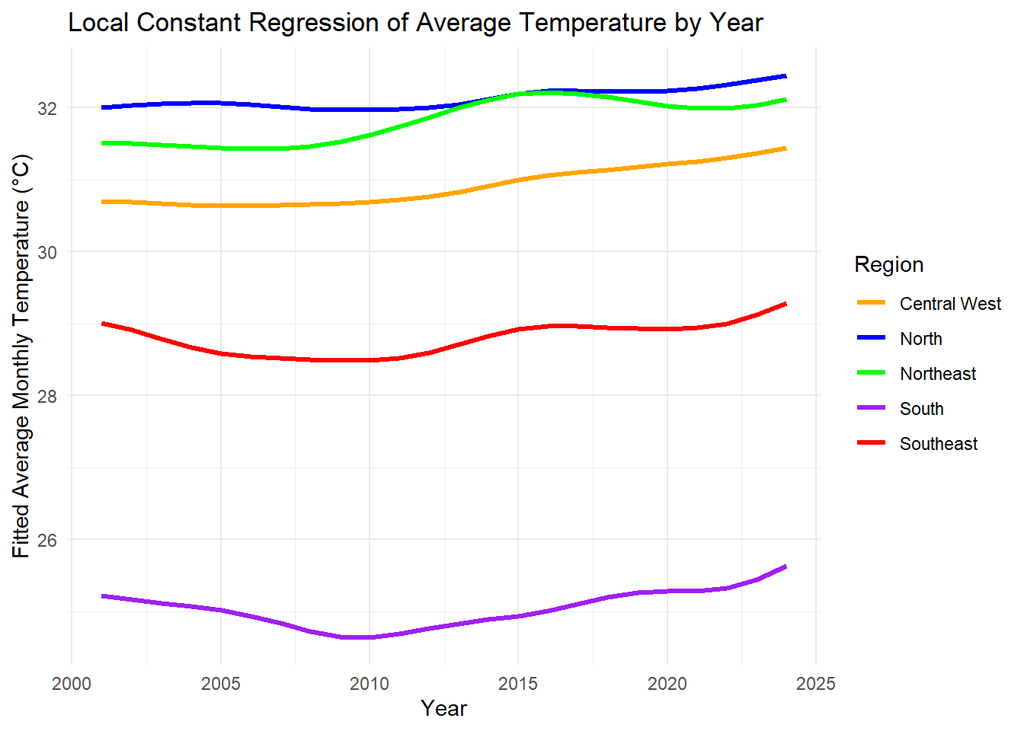

```r
# Step 2: Define a function to perform local constant regression for each region
local_constant_regression = function(region_data, kernel = "gaussian", bandwidth = 2) {
  # Extract year and temperature data
  x = region_data$year # Calendar year
  y = region_data$avg_temp # Average temperature

  # Perform local constant regression using npreg() from the np package
  np_model = npreg(tydat = y, txdat = x, regtype = "lc", bwmethod = "cv.aic", ckertype = kernel, bws = bandwidth)

  # Create a dataframe to hold the fitted values (estimates) for plotting
  fitted_data = data.frame(
    year = np_model$eval$x,
    fitted_temp = np_model$mean,
    region = region_data$region
  )

  return(fitted_data)
}

# Step 3: Apply the regression to each of the 5 macro regions
regions = unique(temperature_states$region) # Extract unique macro regions
fitted_results = list() # List to store results for each region

for (reg in regions) {
  region_data = avg_temp_per_month_region %>%
    filter(region == reg) # Filter data for the current region

  # Perform local constant regression and store the fitted results
  fitted_results[[reg]] = local_constant_regression(region_data)
}

# Step 4: Plot the results for all regions
plot_data = do.call(rbind, fitted_results) %>%
  mutate(region = ifelse(region == 1, "North",
                         ifelse(region == 2, "Northeast",
                                ifelse(region == 3, "Southeast",
                                       ifelse(region == 4, "South",
                                              "Central West")))))

ggplot(plot_data, aes(x = year, y = fitted_temp, color = region)) +
  geom_line(linewidth = 1.2) +
  labs(title = "Local Constant Regression of Average Temperature by Year",
       x = "Year",
       y = "Fitted Average Monthly Temperature (°C)",
       color = "Region") +
  theme_minimal() +
  scale_color_manual(values = c("North" = "blue", "Northeast" = "green",
                                "Southeast" = "red", "South" = "purple",
                                "Central West" = "orange"))
```